# Modul 3: Statistical Process Control (SPC) dan Analisis Kapabilitas

Immantaka Juniarsa

05 November 2026

```r
suppressPackageStartupMessages({ library(dplyr); library(tidyr); library(ggplot2); library(qcc) })
source("R/plot_theme.R"); source("R/spc.R")
pastikan_utf8()   # simbol ° dan × pada grafik tergambar benar di lokal apa pun
ph1 <- read.csv("data/raw/spc_fase1.csv")
ph2 <- read.csv("data/raw/spc_fase2.csv")
att <- read.csv("data/raw/spc_atribut.csv")

# Ubah ke matriks subgrup x pengukuran (format yang dipakai qcc dan fungsi spc.R)
to_matrix <- function(df) {
  as.matrix(df %>% pivot_wider(id_cols = subgroup, names_from = obs,
                               values_from = diameter) %>% dplyr::select(-subgroup))
}
m1 <- to_matrix(ph1); m2 <- to_matrix(ph2)
LSL <- 49.35; USL <- 50.65; TARGET <- 50.00   # spesifikasi diameter poros (mm)
```

## 1. Konteks

Sebuah lini pemesinan memproduksi poros dengan spesifikasi diameter **50 ± 0.65 mm** (LSL = 49.35, USL = 50.65). Setiap jam diambil **subgrup 5 unit**. Tahapan analisis mengikuti Montgomery (2013):

1. **Fase I** (25 subgrup): bangun peta R dan X-bar, buang penyebab khusus, tetapkan batas kendali.
2. **Kapabilitas**: Cp, Cpk (jangka pendek) dan Pp, Ppk (jangka panjang).
3. **Peta p** untuk atribut cacat per lot.
4. **Fase II** (15 subgrup): pantau proses dengan batas fase I dan aturan Western Electric.

> Data disimulasikan (`simulate_spc()`, `set.seed(2024)`): fase I stabil (μ = 50,00; σ = 0,20), fase II bergeser +0,15 mm (0,75σ) mulai subgrup ke-6, dan lot 18–19 pada data atribut mengalami lonjakan cacat. Fungsi SPC di `R/spc.R` ditulis manual dan diverifikasi terhadap paket `qcc` di dokumen ini.

## 2. Fase I: peta R dan X-bar

Peta R dibaca **lebih dahulu**: batas X-bar bergantung pada R-bar, sehingga variabilitas harus stabil sebelum rata-rata dinilai.

```r
lim <- xbar_r_limits(m1)
k   <- spc_constants(lim$n)
knitr::kable(k, caption = "Konstanta peta kendali untuk n = 5 (Montgomery, Appendix VI)")
```

Konstanta peta kendali untuk n = 5 (Montgomery, Appendix VI)

|  | n | A2 | D3 | D4 | d2 | c4 |
| --- | --- | --- | --- | --- | --- | --- |
| 4 | 5 | 0.577 | 0 | 2.114 | 2.326 | 0.94 |

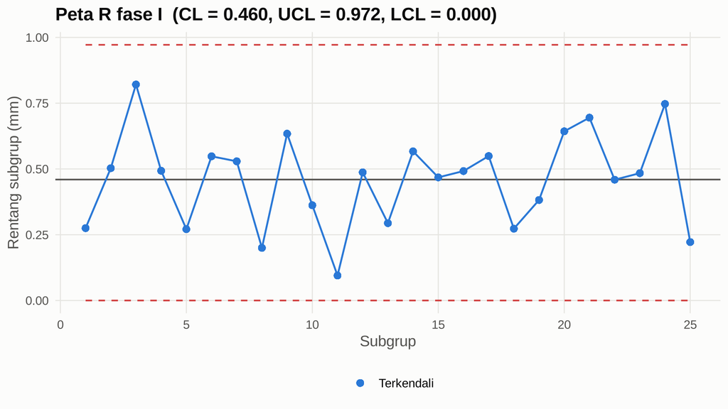

Peta R fase I

```r
r_signal <- lim$r > lim$r_ucl | lim$r < lim$r_lcl
p_r <- plot_control_chart(lim$r, lim$r_cl, lim$r_ucl, lim$r_lcl, r_signal,
                          title = sprintf("Peta R fase I  (CL = %.3f, UCL = %.3f, LCL = %.3f)",
                                          lim$r_cl, lim$r_ucl, lim$r_lcl),
                          ylab = "Rentang subgrup (mm)")
p_r
```

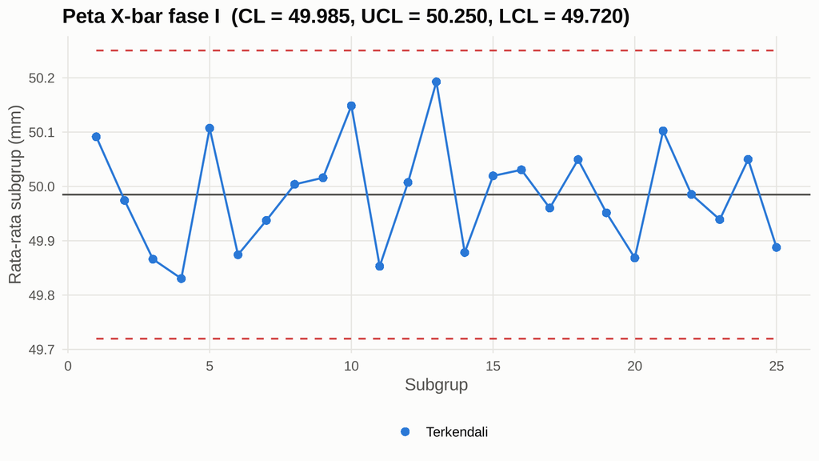

Peta X-bar fase I

```r
sigma_xbar <- lim$sigma_within / sqrt(lim$n)
we1 <- western_electric(lim$xbar, lim$xbar_cl, sigma_xbar)
p_x <- plot_control_chart(lim$xbar, lim$xbar_cl, lim$xbar_ucl, lim$xbar_lcl, we1$any_signal,
                          title = sprintf("Peta X-bar fase I  (CL = %.3f, UCL = %.3f, LCL = %.3f)",
                                          lim$xbar_cl, lim$xbar_ucl, lim$xbar_lcl),
                          ylab = "Rata-rata subgrup (mm)")
p_x
```

```r
simpan_grafik(p_x, "03_xbar_chart_fase1")
```

### 2.1 Aturan Western Electric pada fase I

```r
we_summary <- we1 %>% summarise(`Aturan 1 (>3σ)` = sum(rule1), `Aturan 2 (2/3 >2σ)` = sum(rule2),
                                `Aturan 3 (4/5 >1σ)` = sum(rule3), `Aturan 4 (8 sisi sama)` = sum(rule4))
knitr::kable(we_summary, caption = "Jumlah subgrup fase I yang memicu tiap aturan")
```

Jumlah subgrup fase I yang memicu tiap aturan

| Aturan 1 (>3σ) | Aturan 2 (2/3 >2σ) | Aturan 3 (4/5 >1σ) | Aturan 4 (8 sisi sama) |
| --- | --- | --- | --- |
| 0 | 0 | 0 | 0 |

```r
n_signal1 <- sum(we1$any_signal) + sum(r_signal)
```

**Kesimpulan fase I:** tidak ada sinyal pada peta R maupun X-bar; proses dinyatakan terkendali secara statistik dan batas kendali dapat dipakai untuk fase II.

### 2.2 Verifikasi terhadap paket `qcc`

```r
q_x <- qcc::qcc(m1, type = "xbar", plot = FALSE)
q_r <- qcc::qcc(m1, type = "R",    plot = FALSE)
verif <- data.frame(
  statistik = c("X-bar CL", "X-bar UCL", "X-bar LCL", "R CL", "R UCL", "R LCL", "sigma within"),
  manual = c(lim$xbar_cl, lim$xbar_ucl, lim$xbar_lcl, lim$r_cl, lim$r_ucl, lim$r_lcl, lim$sigma_within),
  qcc    = c(q_x$center, q_x$limits[1, "UCL"], q_x$limits[1, "LCL"],
             q_r$center, q_r$limits[1, "UCL"], q_r$limits[1, "LCL"], q_x$std.dev)
) %>% mutate(selisih = manual - qcc)
knitr::kable(verif %>% mutate(across(where(is.numeric), ~ round(.x, 5))),
             caption = "Batas kendali manual (spc.R) vs qcc")
```

Batas kendali manual (spc.R) vs qcc

| statistik | manual | qcc | selisih |
| --- | --- | --- | --- |
| X-bar CL | 49.98495 | 49.98495 | 0.00000 |
| X-bar UCL | 50.25021 | 50.25012 | 0.00009 |
| X-bar LCL | 49.71969 | 49.71978 | -0.00009 |
| R CL | 0.45972 | 0.45972 | 0.00000 |
| R UCL | 0.97185 | 0.97206 | -0.00022 |
| R LCL | 0.00000 | 0.00000 | 0.00000 |
| sigma within | 0.19764 | 0.19764 | 0.00000 |

## 3. Analisis kapabilitas proses

```r
cap <- capability_indices(as.vector(m1), LSL, USL, lim$sigma_within, target = TARGET)
knitr::kable(cap %>% mutate(across(everything(), ~ signif(.x, 4))),
             caption = "Indeks kapabilitas fase I")
```

Indeks kapabilitas fase I

| mean | sigma_within | sigma_overall | Cp | Cpk | Pp | Ppk | Cpm | ppm_expected |
| --- | --- | --- | --- | --- | --- | --- | --- | --- |
| 49.98 | 0.1976 | 0.2038 | 1.096 | 1.071 | 1.063 | 1.038 | 1.093 | 1041 |

```r
# process.capability() di qcc selalu menggambar; gambar dialihkan ke perangkat kosong
grDevices::pdf(NULL)
pc <- qcc::process.capability(q_x, spec.limits = c(LSL, USL), target = TARGET, print = FALSE)
invisible(grDevices::dev.off())
```

| Indeks | Manual | qcc | Makna |
| --- | --- | --- | --- |
| Cp | 1.096 | 1.096 | Potensi proses jika terpusat (σ within) |
| Cpk | 1.071 | 1.071 | Kapabilitas aktual, memperhitungkan posisi rata-rata |
| Cpm | 1.093 | 1.093 | Penalti terhadap deviasi dari target |
| Pp | 1.063 | - | Potensi jangka panjang (σ overall) |
| Ppk | 1.038 | - | Kinerja jangka panjang |

Perkiraan unit di luar spesifikasi: **1041 ppm** (0.104 %). Rasio σ overall / σ within = 1.031 (≈ 1 → tidak ada variasi antar-subgrup berarti).

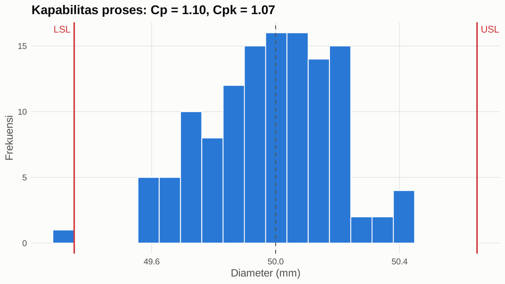

Histogram fase I dengan batas spesifikasi

```r
st <- pal_status()
p_cap <- ggplot(data.frame(x = as.vector(m1)), aes(x)) +
  geom_histogram(bins = 20, fill = pal_kategori()[1], colour = "#fcfcfb") +
  geom_vline(xintercept = c(LSL, USL), colour = st["critical"], linewidth = 0.8) +
  geom_vline(xintercept = TARGET, colour = st["neutral"], linetype = "dashed") +
  annotate("text", x = c(LSL, USL), y = Inf, label = c("LSL", "USL"), vjust = 1.5,
           hjust = c(1.2, -0.2), colour = st["critical"]) +
  labs(title = sprintf("Kapabilitas proses: Cp = %.2f, Cpk = %.2f", cap$Cp, cap$Cpk),
       x = "Diameter (mm)", y = "Frekuensi") +
  theme_portofolio()
p_cap
```

```r
simpan_grafik(p_cap, "03_kapabilitas_proses")
```

**Interpretasi:** Cpk berada di antara 1,00 dan 1,33, proses marginal: memenuhi spesifikasi tetapi tanpa margin aman; pengurangan variasi diperlukan untuk mencapai target 1,33. Karena Cp ≈ Cpk, masalahnya bukan pemusatan melainkan **lebar variasi** relatif terhadap toleransi.

## 4. Peta p untuk atribut cacat

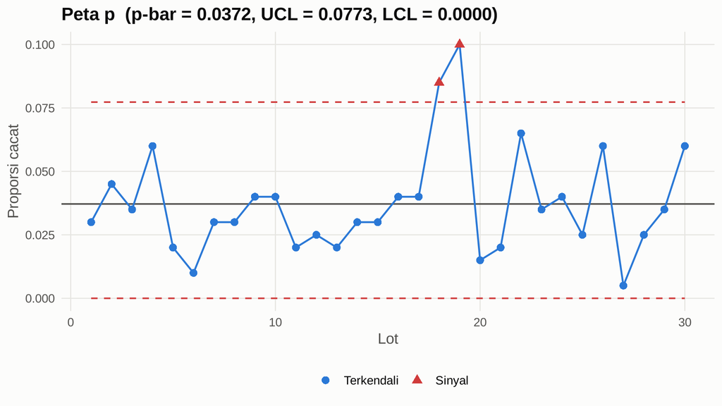

Peta p proporsi cacat per lot

```r
pl <- p_chart_limits(att$defectives, att$sample_size)
p_p <- plot_control_chart(pl$p, pl$pbar, pl$ucl, pl$lcl, pl$out_of_control,
                          title = sprintf("Peta p  (p-bar = %.4f, UCL = %.4f, LCL = %.4f)",
                                          pl$pbar, pl$ucl[1], pl$lcl[1]),
                          ylab = "Proporsi cacat") + labs(x = "Lot")
p_p
```

```r
simpan_grafik(p_p, "03_p_chart")
q_p <- qcc::qcc(att$defectives, sizes = att$sample_size, type = "p", plot = FALSE)
lot_ooc <- att$lot[pl$out_of_control]
```

- p-bar manual = 0.0372 vs qcc = 0.0372; UCL manual = 0.0773 vs qcc = 0.0773.
- Lot di luar batas kendali: 18, 19 (qcc menandai: 18, 19).

```r
knitr::kable(att %>% mutate(p = round(pl$p, 4), status = ifelse(pl$out_of_control, "DI LUAR KENDALI", "")) %>%
               filter(pl$out_of_control | lot %in% c(17, 20)),
             caption = "Lot yang memberi sinyal beserta lot tetangganya")
```

Lot yang memberi sinyal beserta lot tetangganya

| lot | sample_size | defectives | p | status |
| --- | --- | --- | --- | --- |
| 17 | 200 | 8 | 0.040 |  |
| 18 | 200 | 17 | 0.085 | DI LUAR KENDALI |
| 19 | 200 | 20 | 0.100 | DI LUAR KENDALI |
| 20 | 200 | 3 | 0.015 |  |

## 5. Fase II: pemantauan dan deteksi pergeseran

Batas kendali **fase I dibekukan** dan diterapkan pada 15 subgrup baru. Pergeseran yang ditanam hanya 0,75σ. Peta Shewhart klasik (aturan 1) lambat mendeteksinya, sehingga aturan Western Electric dan peta CUSUM dipakai sebagai pelengkap.

```r
xbar2 <- rowMeans(m2); r2 <- apply(m2, 1, function(v) max(v) - min(v))
we2 <- western_electric(xbar2, lim$xbar_cl, sigma_xbar)
first_signal <- if (any(we2$any_signal)) min(which(we2$any_signal)) else NA
rules_hit <- we2 %>% filter(any_signal) %>%
  mutate(aturan = apply(dplyr::select(., rule1:rule4), 1,
                        function(r) paste(which(r), collapse = ","))) %>%
  dplyr::select(index, value, z, aturan)
knitr::kable(rules_hit %>% mutate(across(c(value, z), ~ round(.x, 3))),
             caption = "Subgrup fase II yang memicu aturan Western Electric")
```

Subgrup fase II yang memicu aturan Western Electric

| index | value | z | aturan |
| --- | --- | --- | --- |
| 6 | 50.218 | 2.634 | 2 |
| 7 | 50.016 | 0.351 | 2 |
| 8 | 50.266 | 3.184 | 1,2 |
| 9 | 50.198 | 2.408 | 2,3 |
| 10 | 50.177 | 2.173 | 2,3 |
| 11 | 50.266 | 3.177 | 1,2,3,4 |
| 12 | 50.173 | 2.130 | 2,3,4 |
| 13 | 50.198 | 2.408 | 2,3,4 |
| 14 | 50.201 | 2.444 | 2,3,4 |
| 15 | 50.263 | 3.143 | 1,2,3,4 |

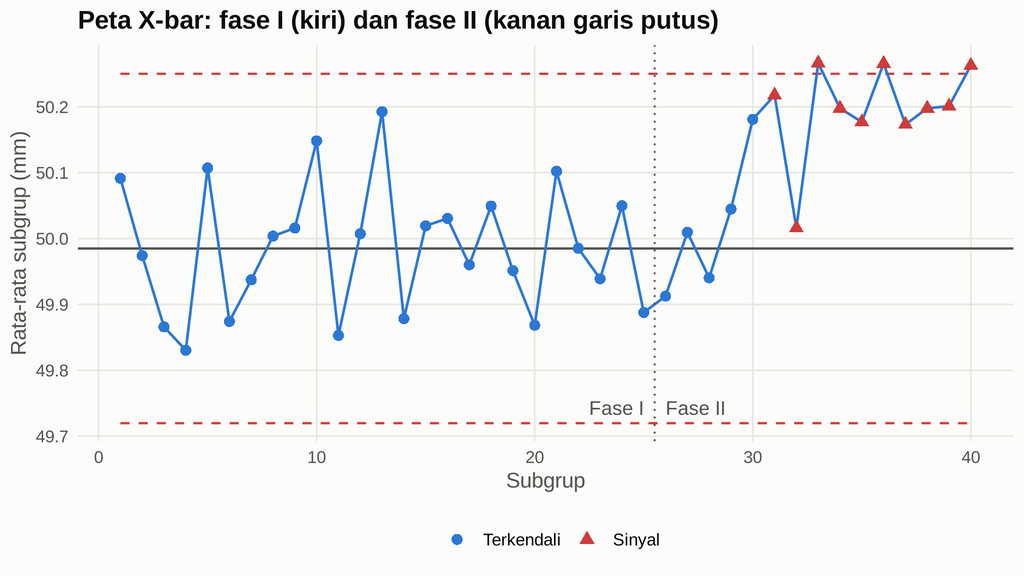

Peta X-bar gabungan fase I dan II (batas dari fase I)

```r
all_xbar <- c(lim$xbar, xbar2)
all_sig  <- c(we1$any_signal, we2$any_signal)
p_x2 <- plot_control_chart(all_xbar, lim$xbar_cl, lim$xbar_ucl, lim$xbar_lcl, all_sig,
                           title = "Peta X-bar: fase I (kiri) dan fase II (kanan garis putus)",
                           ylab = "Rata-rata subgrup (mm)", phase_break = nrow(m1)) +
  # Label fase diletakkan di dekat LCL (area kosong) agar tidak menutupi titik data
  annotate("text", x = nrow(m1) + 1, y = lim$xbar_lcl, label = "Fase II",
           hjust = 0, vjust = -0.6, colour = "#52514e") +
  annotate("text", x = nrow(m1), y = lim$xbar_lcl, label = "Fase I",
           hjust = 1, vjust = -0.6, colour = "#52514e")
p_x2
```

```r
simpan_grafik(p_x2, "03_xbar_chart_fase2")
```

### 5.1 CUSUM sebagai detektor pergeseran kecil

CUSUM mengakumulasi deviasi dari target sehingga lebih peka terhadap pergeseran 0,5–1,5σ. Parameter standar: k = 0,5σ, h = 5σ (dalam satuan σ rata-rata subgrup).

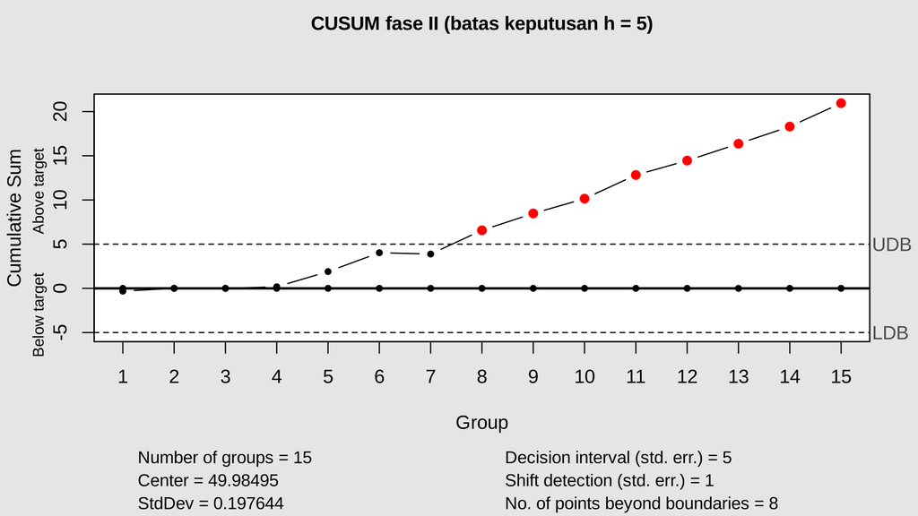

Peta CUSUM fase II (qcc)

```r
cs <- qcc::cusum(m2, center = lim$xbar_cl, std.dev = lim$sigma_within,
                 decision.interval = 5, se.shift = 1, plot = TRUE,
                 title = "CUSUM fase II (batas keputusan h = 5)")
```

```r
cusum_first <- if (length(cs$violations$upper)) min(cs$violations$upper) else NA
```

| Metode | Subgrup fase II pertama yang memberi sinyal |
| --- | --- |
| Shewhart aturan 1 saja (> 3σ) | 8 |
| Western Electric (aturan 1–4) | 6 |
| CUSUM (k = 0,5; h = 5) | 8 |

Pergeseran sebenarnya dimulai pada subgrup ke-6 fase II. Rata-rata subgrup 6–15 = 50.198 mm vs garis tengah 49.985 mm (selisih 0.213 mm ≈ 1.08σ).

## 6. Rekomendasi QC

1. **Proses fase I stabil** dan batas kendali (X-bar: 49.72–50.25 mm; R: 0–0.972 mm) layak dijadikan standar pemantauan.
2. **Kapabilitas marginal** (Cpk = 1.07, ≈ 1041 ppm). Target Cpk ≥ 1,33 menuntut σ within turun dari 0.198 ke ≤ 0.163 mm. Karena itu, prioritaskan pengurangan variasi (kalibrasi alat, keausan pahat, bahan baku), bukan penyetelan pusat.
3. **Pergeseran kecil +0,75σ** pada fase II terdeteksi aturan Western Electric pada subgrup ke-6 (0 subgrup setelah pergeseran dimulai); peta Shewhart aturan 1 saja juga mendeteksinya. Terapkan aturan Western Electric atau CUSUM pada *dashboard* lini secara rutin.
4. **Lot 18 dan 19** pada peta p harus diinvestigasi (penyebab khusus: pergantian shift, batch bahan, atau mesin); bila penyebab ditemukan, hitung ulang batas tanpa lot tersebut.
5. Dokumentasikan rencana reaksi (OCAP) untuk setiap jenis sinyal agar operator tahu tindakan yang harus diambil.

### Padanan di Minitab / SPSS

Minitab: *Stat › Control Charts › Variables Charts for Subgroups › Xbar-R*, *Stat › Quality Tools › Capability Analysis › Normal*, *Stat › Control Charts › Attributes Charts › P*, *Time-Weighted Charts › CUSUM*. SPSS: *Analyze › Quality Control › Control Charts*. Rincian di `docs/padanan_spss_minitab.md`.